# Final

# Introduction

The project I am exploring is trying to analyze the distribution of the types of crimes committed in Chicago. This analysis can help determine what types of crimes are most common. Using this information we can then enact policies that target these particular crimes. The data set we will use contains data about crimes in Chicago starting from 2001. This may be too broad so we will focus on data from years 2013 to 2018. And from this we will attempt to predict the distributions of crimes in year 2019.

I acquired this data from the link listed below: https://catalog.data.gov/dataset/crimes-2001-to-present-398a4

In determining the accuracy and legitimacy of data, it is important to look at the sources. My particular data is acquired from the government and published as an open source data set. It was provided by the Chicago Police Department’s Citizen Law Enforcement Analysis and Reporting system. So it is indeed a reliable source of data in regards to crimes in Chicago.

# Data Extraction

To start, I will extract the csv file provided in the link above and assign it to a variable dt.

```r
library(tidyverse)
```

```r
library(stringr)
library(ggplot2)
library(dplyr)
library(tidyr)
library(ISLR)
library(broom)
```

```r
# I will leave this chunk of code separate from the rest because it takes a while to process such a large csv file
dt <- read_csv("C:/Users/Elin/Documents/CMSC 320/Crimes_2001_to_Present_Chicago.csv")
dt
```

```
## # A tibble: 6,870,908 x 30
##        ID `Case Number` Date  Block IUCR  `Primary Type` Description
##     <dbl> <chr>         <chr> <chr> <chr> <chr>          <chr>
##  1 1.17e7 JC260661      05/1~ 026X~ 0486  BATTERY        DOMESTIC B~
##  2 1.17e7 JC260675      05/1~ 070X~ 0860  THEFT          RETAIL THE~
##  3 1.17e7 JC260664      05/1~ 004X~ 143A  WEAPONS VIOLA~ UNLAWFUL P~
##  4 1.17e7 JC260678      05/1~ 104X~ 1320  CRIMINAL DAMA~ TO VEHICLE
##  5 1.17e7 JC260657      05/1~ 013X~ 2820  OTHER OFFENSE  TELEPHONE ~
##  6 1.17e7 JC260663      05/1~ 008X~ 141A  WEAPONS VIOLA~ UNLAWFUL U~
##  7 1.17e7 JC260677      05/1~ 039X~ 143A  WEAPONS VIOLA~ UNLAWFUL P~
##  8 1.17e7 JC265327      05/1~ 005X~ 0560  ASSAULT        SIMPLE
##  9 1.17e7 JC260640      05/1~ 014X~ 0460  BATTERY        SIMPLE
## 10 1.17e7 JC260651      05/1~ 044X~ 0860  THEFT          RETAIL THE~
## # ... with 6,870,898 more rows, and 23 more variables: `Location
## #   Description` <chr>, Arrest <lgl>, Domestic <lgl>, Beat <chr>,
## #   District <chr>, Ward <dbl>, `Community Area` <dbl>, `FBI Code` <chr>,
## #   `X Coordinate` <dbl>, `Y Coordinate` <dbl>, Year <dbl>, `Updated
## #   On` <chr>, Latitude <dbl>, Longitude <dbl>, Location <chr>,
## #   `Historical Wards 2003-2015` <dbl>, `Zip Codes` <dbl>, `Community
## #   Areas` <dbl>, `Census Tracts` <dbl>, Wards <dbl>, `Boundaries - ZIP
## #   Codes` <dbl>, `Police Districts` <dbl>, `Police Beats` <dbl>
```

Each row of the table displayed above is an *entity* and each column is an *attribute value* for that entity. This is all encapsulated by the variable dt which is a rectangular dataset, *data.frame*.

Each row displays a case of crime. This means our entities would be each case of crime. And then the attribute values describe each entity. In this case it would be like the case number, date, type of crime, etc.

# Cleaning Up Data

Since we are looking to find distribution of the types of crime. Lets clean up the data and remove some unnecessary attribute values. We can do this by using a pipeline (%>%) which transforms one data frame into another. We will then use *select* based on attributes.

```r
dt <- dt %>%
  select(`Case Number`, Date,`Primary Type`, Description, Latitude, Longitude)
dt
```

```
## # A tibble: 6,870,908 x 6
##    `Case Number` Date      `Primary Type`  Description   Latitude Longitude
##    <chr>         <chr>     <chr>           <chr>            <dbl>     <dbl>
##  1 JC260661      05/12/20~ BATTERY         DOMESTIC BAT~     41.9     -87.7
##  2 JC260675      05/12/20~ THEFT           RETAIL THEFT      41.8     -87.7
##  3 JC260664      05/12/20~ WEAPONS VIOLAT~ UNLAWFUL POS~     41.8     -87.6
##  4 JC260678      05/12/20~ CRIMINAL DAMAGE TO VEHICLE        41.7     -87.6
##  5 JC260657      05/12/20~ OTHER OFFENSE   TELEPHONE TH~     41.7     -87.7
##  6 JC260663      05/12/20~ WEAPONS VIOLAT~ UNLAWFUL USE~     41.8     -87.6
##  7 JC260677      05/12/20~ WEAPONS VIOLAT~ UNLAWFUL POS~     41.9     -87.7
##  8 JC265327      05/12/20~ ASSAULT         SIMPLE            41.9     -87.6
##  9 JC260640      05/12/20~ BATTERY         SIMPLE            41.9     -87.6
## 10 JC260651      05/12/20~ THEFT           RETAIL THEFT      41.9     -87.7
## # ... with 6,870,898 more rows
```

To do this we would need to use *filter* which will select entities based on attribute value. Which in our case would be year. The code to get this attribute value from the date is listed below.

```r
# Extract year from Date
# An option would be to convert to datetime object however it takes more computation power to do that so
# I used just the str_extract method. Which my laptop was able to handle better.
dt$Year <- str_extract(dt$Date,"[0-9]{4}")
dt
```

```
## # A tibble: 6,870,908 x 7
##    `Case Number` Date   `Primary Type` Description Latitude Longitude Year
##    <chr>         <chr>  <chr>          <chr>          <dbl>     <dbl> <chr>
##  1 JC260661      05/12~ BATTERY        DOMESTIC B~     41.9     -87.7 2019
##  2 JC260675      05/12~ THEFT          RETAIL THE~     41.8     -87.7 2019
##  3 JC260664      05/12~ WEAPONS VIOLA~ UNLAWFUL P~     41.8     -87.6 2019
##  4 JC260678      05/12~ CRIMINAL DAMA~ TO VEHICLE      41.7     -87.6 2019
##  5 JC260657      05/12~ OTHER OFFENSE  TELEPHONE ~     41.7     -87.7 2019
##  6 JC260663      05/12~ WEAPONS VIOLA~ UNLAWFUL U~     41.8     -87.6 2019
##  7 JC260677      05/12~ WEAPONS VIOLA~ UNLAWFUL P~     41.9     -87.7 2019
##  8 JC265327      05/12~ ASSAULT        SIMPLE          41.9     -87.6 2019
##  9 JC260640      05/12~ BATTERY        SIMPLE          41.9     -87.6 2019
## 10 JC260651      05/12~ THEFT          RETAIL THE~     41.9     -87.7 2019
## # ... with 6,870,898 more rows
```

Next we filter based on year.

```r
dt <- dt %>%
  filter(Year >= 2013 & Year <= 2018)
dt
```

```
## # A tibble: 1,650,523 x 7
##    `Case Number` Date   `Primary Type` Description Latitude Longitude Year
##    <chr>         <chr>  <chr>          <chr>          <dbl>     <dbl> <chr>
##  1 JC104662      12/31~ CRIMINAL DAMA~ TO VEHICLE      41.7     -87.7 2018
##  2 JC110056      12/31~ DECEPTIVE PRA~ FINANCIAL ~     41.8     -87.7 2018
##  3 JC100043      12/31~ CRIMINAL DAMA~ TO PROPERTY     41.7     -87.6 2018
##  4 JC100006      12/31~ BATTERY        AGG: HANDS~     41.9     -87.7 2018
##  5 JC100031      12/31~ BATTERY        DOMESTIC B~     41.8     -87.6 2018
##  6 JC100026      12/31~ BATTERY        AGGRAVATED~     41.9     -87.8 2018
##  7 JC100011      12/31~ BATTERY        DOMESTIC B~     41.8     -87.7 2018
##  8 JC100089      12/31~ BATTERY        SIMPLE          41.9     -87.7 2018
##  9 JC101652      12/31~ CRIMINAL DAMA~ TO PROPERTY     41.9     -87.7 2018
## 10 JC101094      12/31~ THEFT          FROM BUILD~     41.9     -87.7 2018
## # ... with 1,650,513 more rows
```

Our data is now cut down to 1.6 million is a still a large sum but more manageable. We now will omit entities with missing values or NA’s for attributes values. Other options to handle missing data may be to imputation for numerical values which involves just inputting the mean of range of values in place of NA. However we won’t do that. The amount of entities with missing values is neglible to the total sum of entities we have.

```r
na.omit(dt)
```

```
## # A tibble: 1,633,645 x 7
##    `Case Number` Date   `Primary Type` Description Latitude Longitude Year
##    <chr>         <chr>  <chr>          <chr>          <dbl>     <dbl> <chr>
##  1 JC104662      12/31~ CRIMINAL DAMA~ TO VEHICLE      41.7     -87.7 2018
##  2 JC110056      12/31~ DECEPTIVE PRA~ FINANCIAL ~     41.8     -87.7 2018
##  3 JC100043      12/31~ CRIMINAL DAMA~ TO PROPERTY     41.7     -87.6 2018
##  4 JC100006      12/31~ BATTERY        AGG: HANDS~     41.9     -87.7 2018
##  5 JC100031      12/31~ BATTERY        DOMESTIC B~     41.8     -87.6 2018
##  6 JC100026      12/31~ BATTERY        AGGRAVATED~     41.9     -87.8 2018
##  7 JC100011      12/31~ BATTERY        DOMESTIC B~     41.8     -87.7 2018
##  8 JC100089      12/31~ BATTERY        SIMPLE          41.9     -87.7 2018
##  9 JC101652      12/31~ CRIMINAL DAMA~ TO PROPERTY     41.9     -87.7 2018
## 10 JC101094      12/31~ THEFT          FROM BUILD~     41.9     -87.7 2018
## # ... with 1,633,635 more rows
```

# Data Transformation and Visualization

Now that we orangized and sorted the data. Lets convert into a more usuable and readable form.

We want to know the distributions between each type. So lets start by finding out the number of occurences for each type of crime.

```r
crimeCounts <- dt %>%
  count(`Primary Type`, sort=TRUE) %>%
  mutate(Percentage = round((n/sum(n))*100,digits = 5))
crimeCounts
```

```
## # A tibble: 33 x 3
##    `Primary Type`           n Percentage
##    <chr>                <int>      <dbl>
##  1 THEFT               381513      23.1
##  2 BATTERY             301662      18.3
##  3 CRIMINAL DAMAGE     175196      10.6
##  4 NARCOTICS           125262       7.59
##  5 ASSAULT             110351       6.69
##  6 OTHER OFFENSE       104205       6.31
##  7 DECEPTIVE PRACTICE  102451       6.21
##  8 BURGLARY             84665       5.13
##  9 MOTOR VEHICLE THEFT  65240       3.95
## 10 ROBBERY              64777       3.92
## # ... with 23 more rows
```

There’s quite of lot of different types of crime. In fact 33 different types. It would be quite difficult analyze so many different types so lets focus on the top 5. This would also make visualization easier.

```r
crimeCounts <- crimeCounts %>%
  slice(1:5)
crimeCounts
```

```
## # A tibble: 5 x 3
##   `Primary Type`       n Percentage
##   <chr>            <int>      <dbl>
## 1 THEFT           381513      23.1
## 2 BATTERY         301662      18.3
## 3 CRIMINAL DAMAGE 175196      10.6
## 4 NARCOTICS       125262       7.59
## 5 ASSAULT         110351       6.69
```

Now lets also make sure our data frame only reflects those cases with the top 5 types of crime.

```r
top5dt <- dt %>%
  filter(`Primary Type` %in% c("THEFT", "BATTERY", "CRIMINAL DAMAGE", "NARCOTICS", "ASSAULT"))
top5dt
```

```
## # A tibble: 1,093,984 x 7
##    `Case Number` Date   `Primary Type` Description Latitude Longitude Year
##    <chr>         <chr>  <chr>          <chr>          <dbl>     <dbl> <chr>
##  1 JC104662      12/31~ CRIMINAL DAMA~ TO VEHICLE      41.7     -87.7 2018
##  2 JC100043      12/31~ CRIMINAL DAMA~ TO PROPERTY     41.7     -87.6 2018
##  3 JC100006      12/31~ BATTERY        AGG: HANDS~     41.9     -87.7 2018
##  4 JC100031      12/31~ BATTERY        DOMESTIC B~     41.8     -87.6 2018
##  5 JC100026      12/31~ BATTERY        AGGRAVATED~     41.9     -87.8 2018
##  6 JC100011      12/31~ BATTERY        DOMESTIC B~     41.8     -87.7 2018
##  7 JC100089      12/31~ BATTERY        SIMPLE          41.9     -87.7 2018
##  8 JC101652      12/31~ CRIMINAL DAMA~ TO PROPERTY     41.9     -87.7 2018
##  9 JC101094      12/31~ THEFT          FROM BUILD~     41.9     -87.7 2018
## 10 JC100004      12/31~ NARCOTICS      POSS: COCA~     41.9     -87.8 2018
## # ... with 1,093,974 more rows
```

We will now try to visualize the data through a graph. A pie chart here would work well with displaying percentages. A source to learn more about displays using pie charts can be found here :http://www.datasciencemadesimple.com/r-pie-chart/.

```r
#First need to reassign percent values
crimeCounts <- crimeCounts %>%
  mutate(Percentage = round((n/sum(n))*100,digits = 5))
crimeCounts
```

```
## # A tibble: 5 x 3
##   `Primary Type`       n Percentage
##   <chr>            <int>      <dbl>
## 1 THEFT           381513       34.9
## 2 BATTERY         301662       27.6
## 3 CRIMINAL DAMAGE 175196       16.0
## 4 NARCOTICS       125262       11.5
## 5 ASSAULT         110351       10.1
```

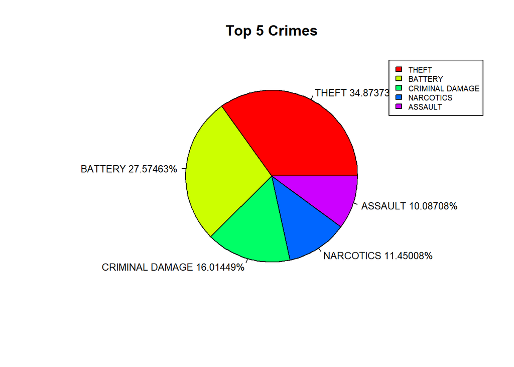

```r
lbls <- paste(crimeCounts$`Primary Type`, crimeCounts$Percentage)
lbls <- paste(lbls, "%", sep="")

# Plot the chart
pie(crimeCounts$n,labels = lbls, col=rainbow(length(lbls)),main="Top 5 Crimes", cex = 0.8)
legend("topright",crimeCounts$`Primary Type`, cex=0.63,fill=rainbow(length(lbls)))
```

Now lets see a histogram of these types.

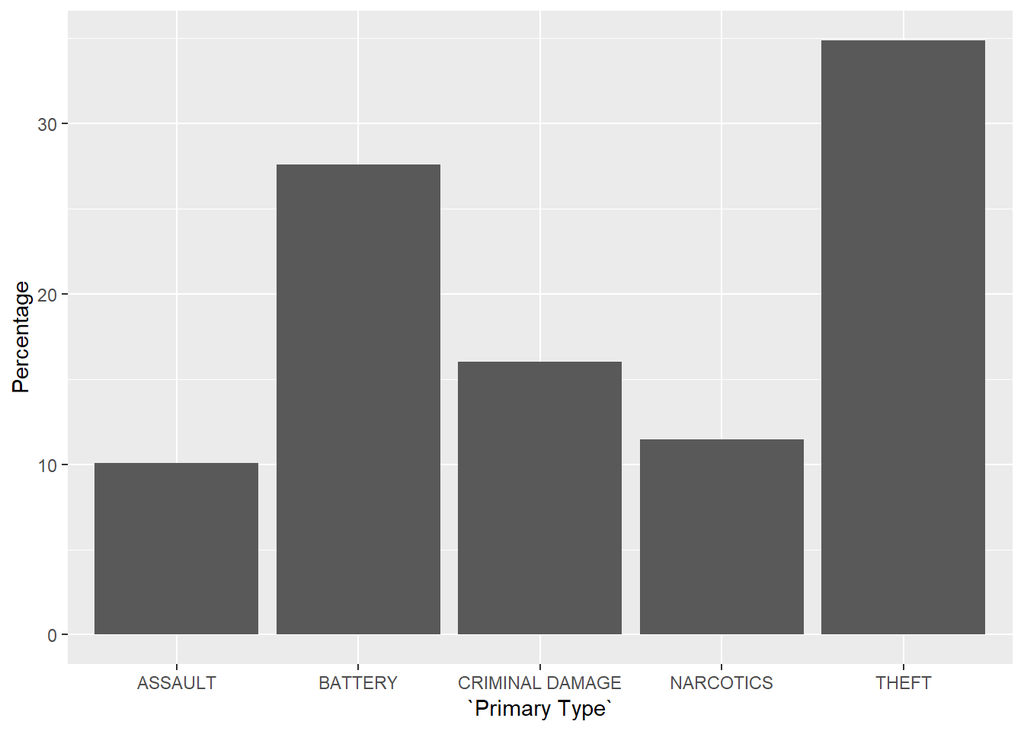

```r
crimeCounts %>%
   ggplot(aes(x=`Primary Type`, y=Percentage)) +
    geom_bar(stat='identity')
```

Now that we see how the overall distributions for the 5 crimes are. Lets see how it is year by year and see if there are any changes.

```r
top5dt
```

```
## # A tibble: 1,093,984 x 7
##    `Case Number` Date   `Primary Type` Description Latitude Longitude Year
##    <chr>         <chr>  <chr>          <chr>          <dbl>     <dbl> <chr>
##  1 JC104662      12/31~ CRIMINAL DAMA~ TO VEHICLE      41.7     -87.7 2018
##  2 JC100043      12/31~ CRIMINAL DAMA~ TO PROPERTY     41.7     -87.6 2018
##  3 JC100006      12/31~ BATTERY        AGG: HANDS~     41.9     -87.7 2018
##  4 JC100031      12/31~ BATTERY        DOMESTIC B~     41.8     -87.6 2018
##  5 JC100026      12/31~ BATTERY        AGGRAVATED~     41.9     -87.8 2018
##  6 JC100011      12/31~ BATTERY        DOMESTIC B~     41.8     -87.7 2018
##  7 JC100089      12/31~ BATTERY        SIMPLE          41.9     -87.7 2018
##  8 JC101652      12/31~ CRIMINAL DAMA~ TO PROPERTY     41.9     -87.7 2018
##  9 JC101094      12/31~ THEFT          FROM BUILD~     41.9     -87.7 2018
## 10 JC100004      12/31~ NARCOTICS      POSS: COCA~     41.9     -87.8 2018
## # ... with 1,093,974 more rows
```